# Le vélo à Paris : comprendre et prévoir le trafic cyclable

Projet de séries chronologiques

Date de publication

15 novembre 2026

**Problématique.** Quelle part du trafic cyclable parisien s’explique par le calendrier, la météo et les événements, et peut-on le prévoir à quelques jours ?

**Réponse courte.** Sur 2021-2025, la semaine, la saison annuelle, le calendrier et la météo expliquent **86 %** de la variance du log du trafic ; la dynamique propre de la série en ajoute **2,2 %**. À un jour, le meilleur modèle (SARIMAX (météo observée)) se trompe en moyenne de **9,8 %**, contre 23,0 % pour la prévision naïve « comme la semaine dernière ».

# 1 Introduction

Paris a vu son trafic cyclable presque doubler entre 2019 et 2026. Les compteurs automatiques de la Ville enregistrent chaque heure le passage des vélos sur les grands axes. Ces données forment une série chronologique riche : une tendance forte, deux saisonnalités (la semaine, l’année), des chocs (grève, confinements, Jeux olympiques) et une forte sensibilité à la météo.

Le projet suit une démarche classique d’analyse de séries chronologiques : description, décomposition, stationnarité, modélisation SARIMA puis SARIMAX, mise en concurrence avec des méthodes alternatives et évaluation des prévisions. Tous les traitements sont faits en R, dans des scripts numérotés (`R/01_import.R` à `R/10_evaluation.R`) ; chaque figure de ce rapport est produite par l’un d’eux.

# 2 Données

## 2.1 Sources

| Source | Contenu | Période |
| --- | --- | --- |
| Ville de Paris (opendata.paris.fr) | Comptages horaires de tous les compteurs vélo | 2018 – nov. 2026 |
| Météo-France, station Paris-Montsouris | Température, pluie, vent (journaliers) | 2018 – nov. 2026 |
| calendrier.api.gouv.fr, data.education.gouv.fr | Jours fériés, vacances scolaires de Paris (zone C) | 2018 – 2027 |

## 2.2 Construction de la série

Additionner simplement tous les compteurs donnerait une fausse tendance : leur nombre passe de 14 en 2018 à près de 170 en 2024. On construit donc un **panel de 27 compteurs** installés avant 2019, fiables (au moins 90 % de jours valides), sans dérive de niveau et actifs jusqu’à la fin. Les jours de panne (2,7 % des jours compteur) sont détectés par comparaison avec le comportement commun des autres compteurs, puis remplacés par une estimation. Ces règles et leurs 16 figures de contrôle sont détaillées dans `R/02_nettoyage.R` et `data/LISEZMOI.md`.

La série finale compte **2 872 jours**, du 01/01/2019 au 11/11/2026, avec en moyenne 41 967 vélos par jour.

**Découpage.** Les modèles sont estimés sur la période **juin 2021 – 11 novembre 2025** (après la crise sanitaire, voir la partie 5) et évalués sur la **dernière année, du 12 novembre 2025 au 11 novembre 2026**, jamais utilisée pour l’estimation.

# 3 Exploration

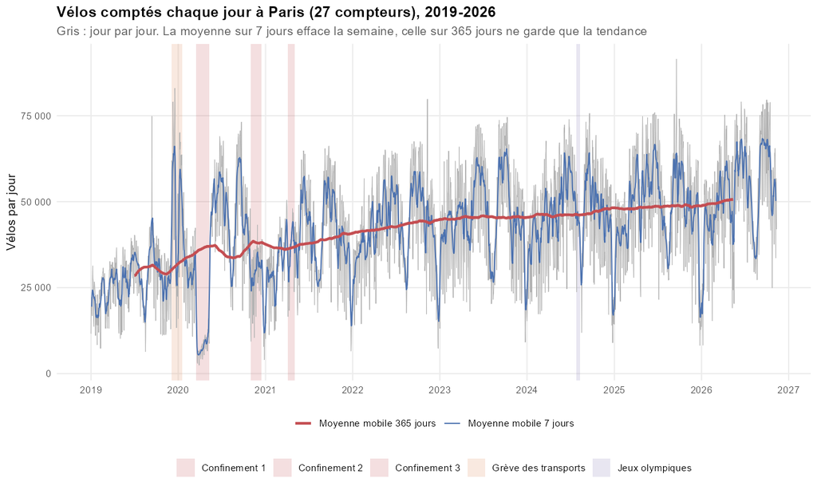

La série complète. Bandes colorées : grève de décembre 2019, trois confinements, Jeux olympiques.

La série montre une **tendance croissante non linéaire** (rebond rapide après 2020 puis croissance plus lente), un **cycle hebdomadaire très régulier** et une **saison annuelle** marquée : creux en août et à Noël, pics en juin et en septembre.

## 3.1 Passage au log

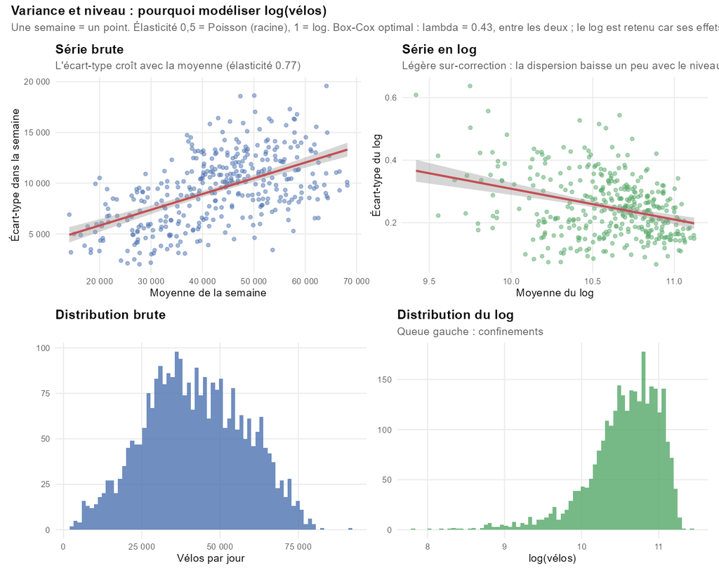

Relation entre niveau et dispersion, et distributions.

L’écart-type hebdomadaire croît avec la moyenne (élasticité 0,77) : le modèle est **multiplicatif**, $X_t = m_t \times s_t \times z_t$, donc additif en log. Le $\lambda$ de Box-Cox optimal (Guerrero) vaut 0,43, entre la racine (comptages de Poisson) et le log. On retient le **log**, qui corrige l’essentiel de l’hétéroscédasticité et permet de lire chaque effet en pourcentage.

## 3.2 Deux saisonnalités

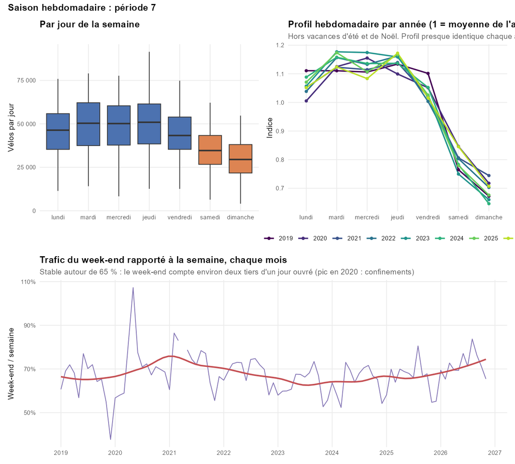

Saison hebdomadaire : profil par jour et par année, rapport week-end / semaine.

Le mardi et le jeudi sont les jours les plus chargés ; le dimanche compte environ 30 % de vélos de moins que la moyenne. Ce profil est remarquablement stable d’une année à l’autre : le week-end représente environ **deux tiers** d’un jour ouvré (0,64 en 2019, 0,66 en 2025). Le vélo parisien est avant tout un mode de déplacement domicile-travail.

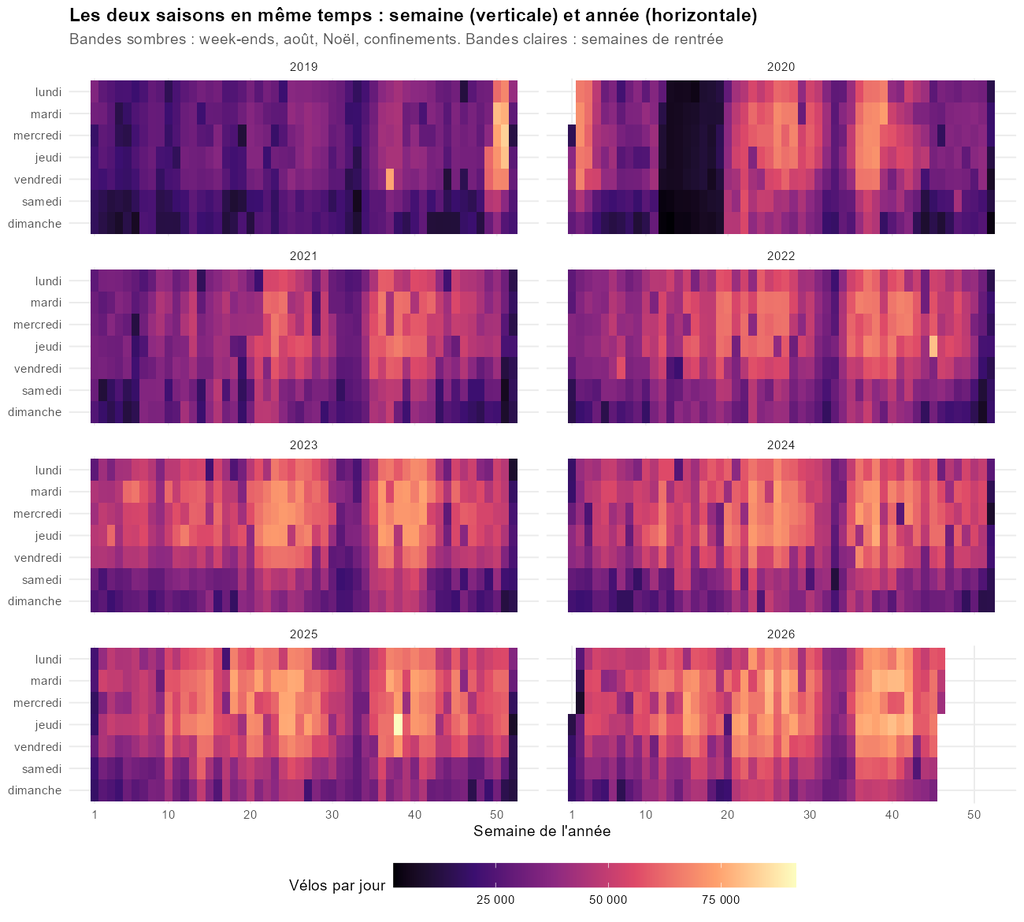

Les deux saisons en même temps : jour de la semaine (vertical) × semaine de l’année (horizontal).

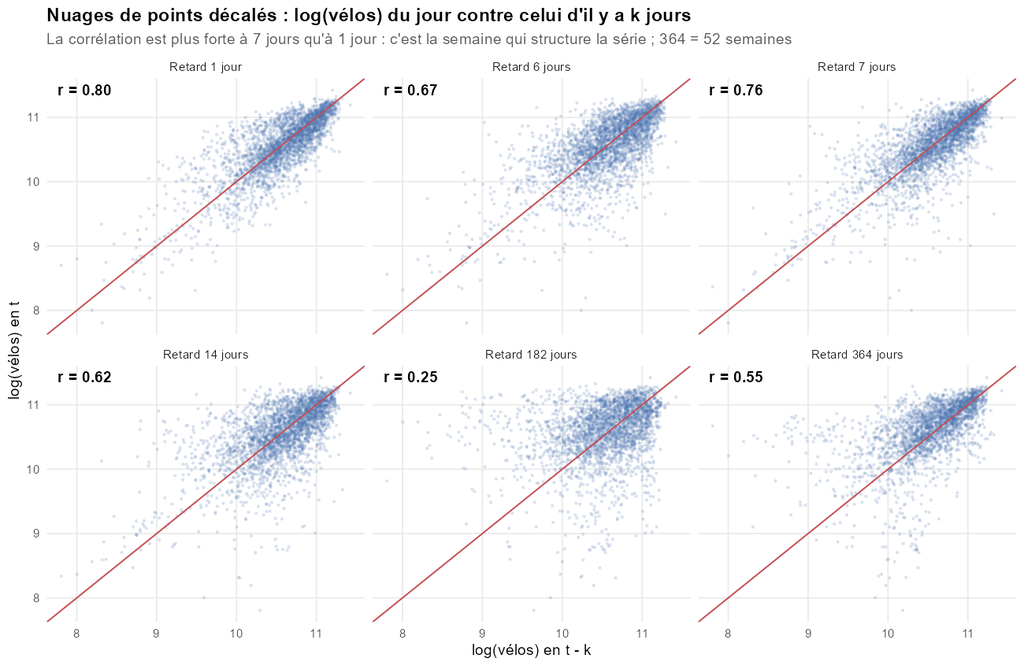

Nuages décalés, ACF et périodogramme.

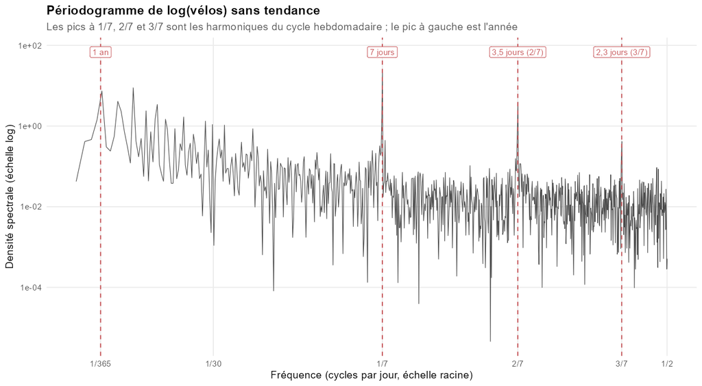

Nuages décalés, ACF et périodogramme.

La corrélation entre deux jours séparés de 7 jours (0,76) dépasse celle à 6 jours (0,67). Le **périodogramme** confirme la structure : des pics aux fréquences 1/7, 2/7 et 3/7 (les harmoniques du cycle hebdomadaire) et un pic à 1/365 (l’année).

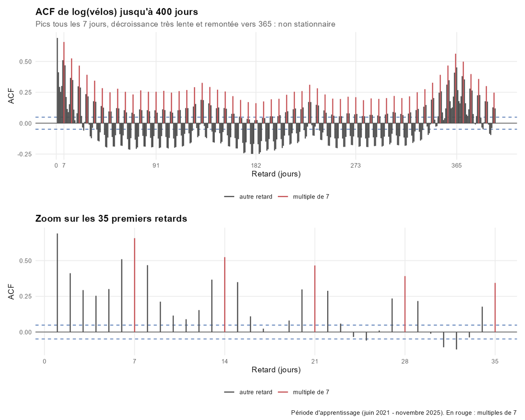

ACF de log(vélos) sur la période d’apprentissage.

L’ACF décroît très lentement, avec des pics tous les 7 jours et une remontée vers 365 : la série brute **n’est pas stationnaire**.

## 3.3 Météo, calendrier et événements

Pour isoler l’effet d’un facteur sans être gêné par la tendance et la semaine, on calcule un **trafic relatif** : le trafic du jour divisé par la médiane des mêmes jours de la semaine, trois semaines avant et trois semaines après.

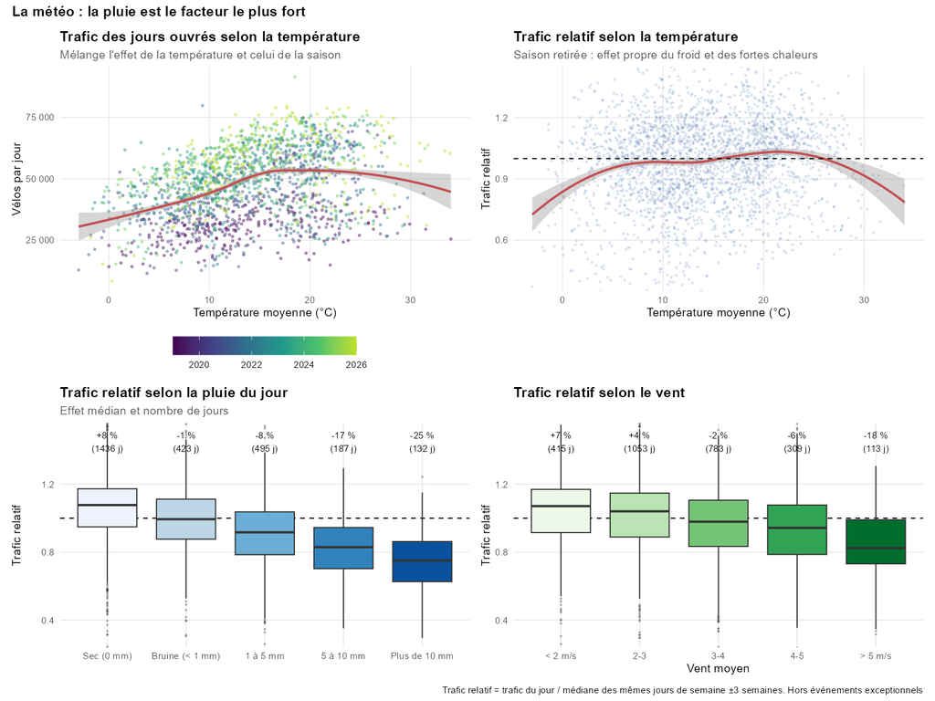

Effet de la température, de la pluie et du vent sur le trafic relatif.

La **pluie** est le facteur météo le plus fort : une journée de plus de 10 mm fait perdre 25 % de vélos. Le froid fait baisser le trafic ; au-delà de 25 °C la courbe redescend légèrement. Le vent a un effet plus modéré.

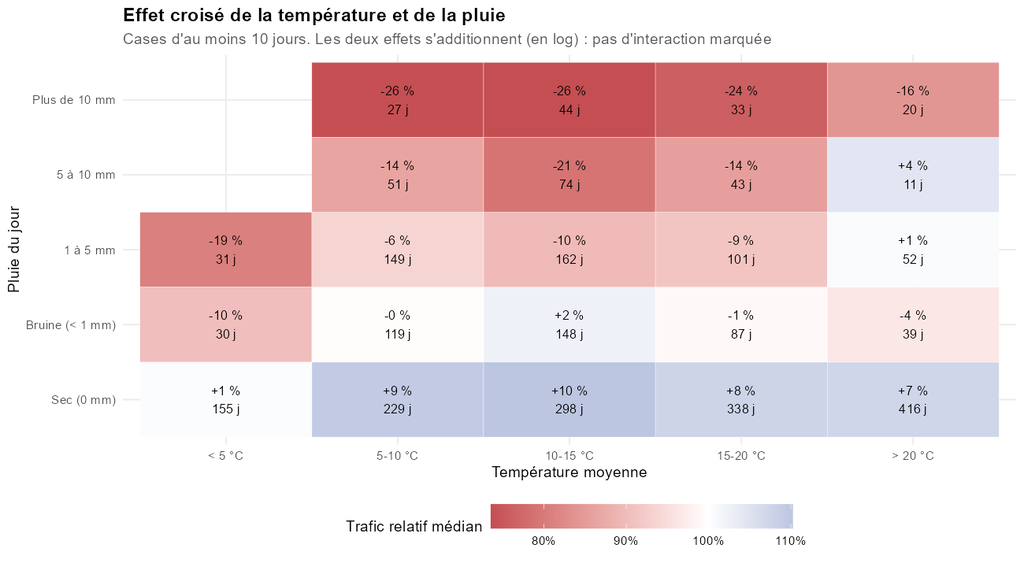

Effet croisé température × pluie.

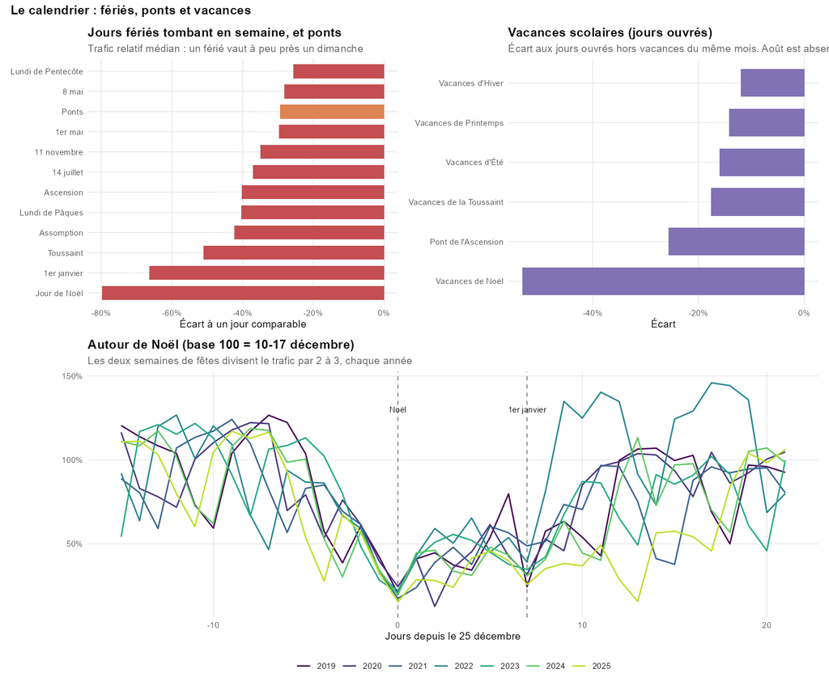

Jours fériés, ponts, vacances scolaires et période de Noël.

Un jour férié en semaine fait perdre 40 % de trafic : il ressemble à un dimanche. Les vacances de Noël divisent le trafic par deux à trois chaque année ; les autres vacances le réduisent de 10 à 25 %.

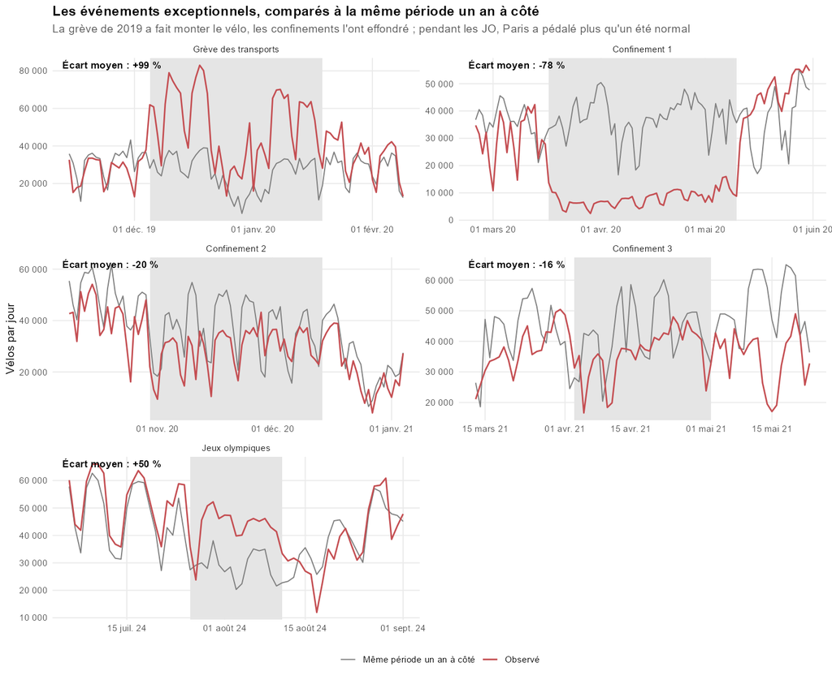

Événements exceptionnels comparés à la même période un an plus tard (ou plus tôt pour les JO).

# 4 Décomposition

## 4.1 Filtrage linéaire

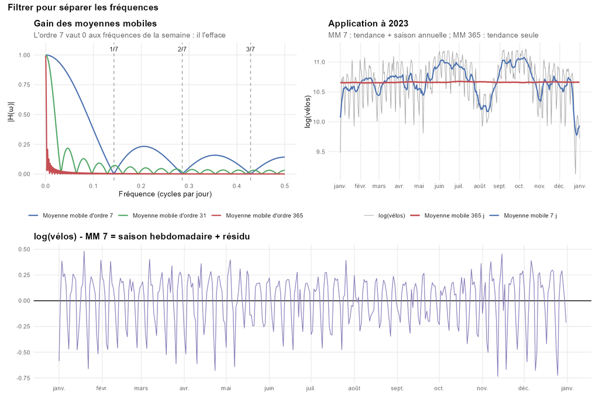

Gain des moyennes mobiles et application à 2023.

La moyenne mobile arithmétique d’ordre 7 a pour fonction de transfert $H(\omega) = \frac{\sin(7\omega/2)}{7 \sin(\omega/2)}$, nulle aux fréquences $2\pi k / 7$ : elle **supprime exactement la saison hebdomadaire** tout en laissant passer les basses fréquences. L’ordre 365 ne garde que la tendance.

## 4.2 Décomposition classique, MSTL et régression de Fourier

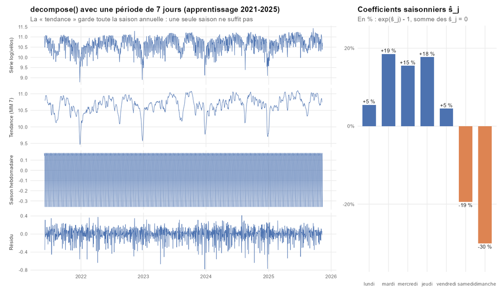

decompose() avec une seule période (7 jours).

Avec une seule saison, la « tendance » de `decompose()` absorbe toute la saison annuelle. Les coefficients saisonniers $\hat s_j$ (somme nulle) donnent le profil de la semaine : mardi +19 %, mercredi +15 %, jeudi +18 %, vendredi +5 %, samedi -19 %, dimanche -30 %, lundi +5 %.

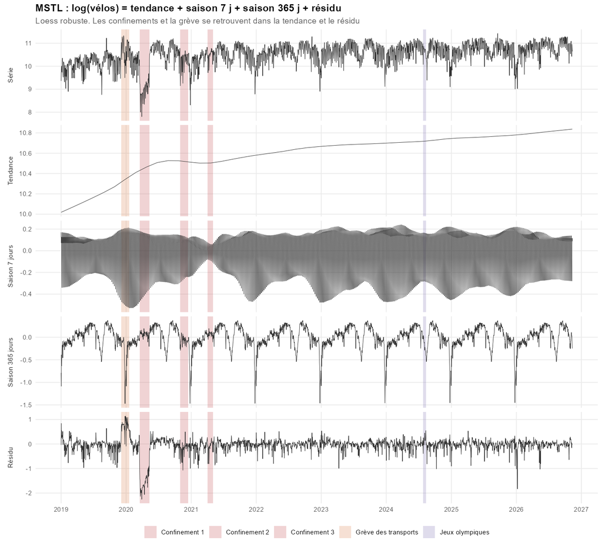

MSTL : tendance, saison de 7 jours, saison de 365 jours et résidu.

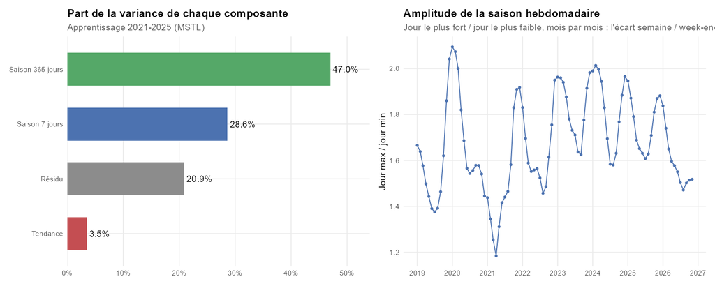

Part de la variance de chaque composante (MSTL) et amplitude de la saison hebdomadaire.

Sur la période d’apprentissage, la **saison annuelle** porte 47 % de la variance, la **semaine** 29 % et la tendance seulement 3,5 %. Le résidu représente encore 21 %. L’écart semaine / week-end est plus grand en hiver qu’en été.

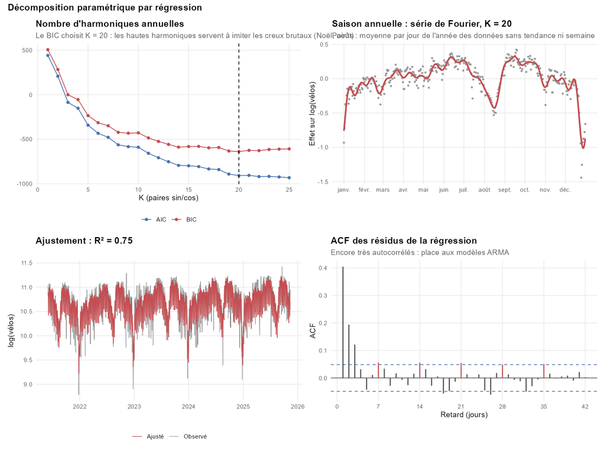

Régression : tendance quadratique + jour de la semaine + série de Fourier annuelle.

Une saison annuelle paramétrique $s_t = \sum_{k=1}^{K} \alpha_k \sin(2\pi k t/365{,}25) + \beta_k \cos(2\pi k t/365{,}25)$ s’ajuste bien, mais le BIC réclame beaucoup d’harmoniques : elles servent à imiter des creux brutaux (Noël, août). Il vaut mieux décrire ces creux par des **indicatrices de calendrier**, ce que fera le SARIMAX. Les résidus de cette régression restent très autocorrélés et dépendent clairement de la pluie et des jours fériés.

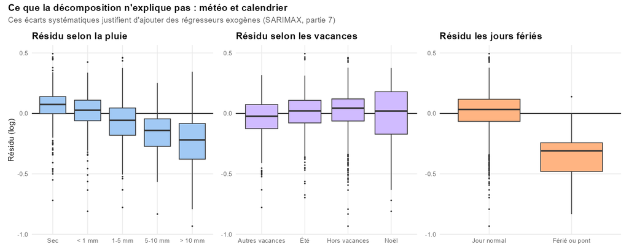

Ce que la décomposition n’explique pas.

## 4.3 Méthode par blocs et filtres complémentaires

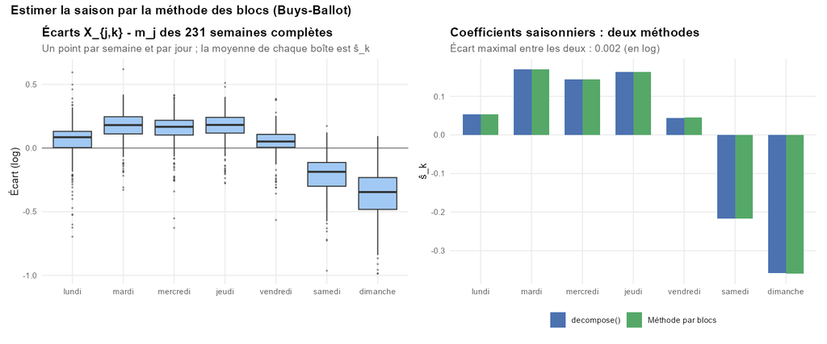

Coefficients saisonniers par la méthode des blocs (Buys-Ballot), comparés à decompose().

La **méthode par blocs** prend chaque semaine complète comme un bloc $j$. On calcule sa moyenne $\hat m_j$, puis $\hat s_k = \frac1J \sum_j (X_{j,k} - \hat m_j)$, dont la somme est nulle automatiquement. Elle redonne les coefficients de `decompose()` à 0,002 près, et les boîtes montrent en plus leur dispersion d’une semaine à l’autre.

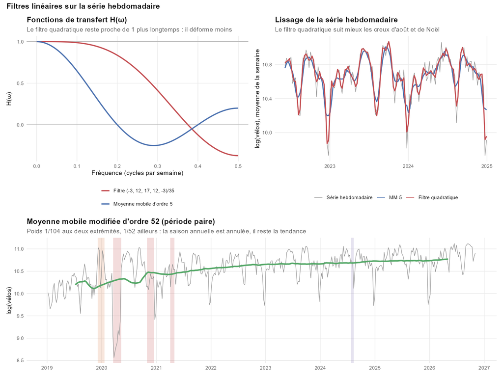

Filtres sur la série hebdomadaire : moyenne mobile d’ordre 5, filtre (-3, 12, 17, 12, -3)/35, moyenne mobile modifiée d’ordre 52.

Sur la série des moyennes hebdomadaires, on compare la moyenne mobile d’ordre 5 au filtre $(-3, 12, 17, 12, -3)/35$. Les deux ont des poids de somme 1, mais seul le second vérifie aussi $\sum k^2 c_k = 0$ : il **conserve les tendances quadratiques** et aplatit moins les creux d’août et de Noël. La période annuelle vaut 52 semaines, un nombre pair : c’est le cas où il faut la **moyenne mobile modifiée**, avec des poids $1/104$ aux extrémités et $1/52$ ailleurs. Elle annule la saison annuelle et ne garde que la tendance. Avec les données journalières, les périodes 7 et 365 sont impaires et la moyenne arithmétique simple suffit.

## 4.4 Prophet

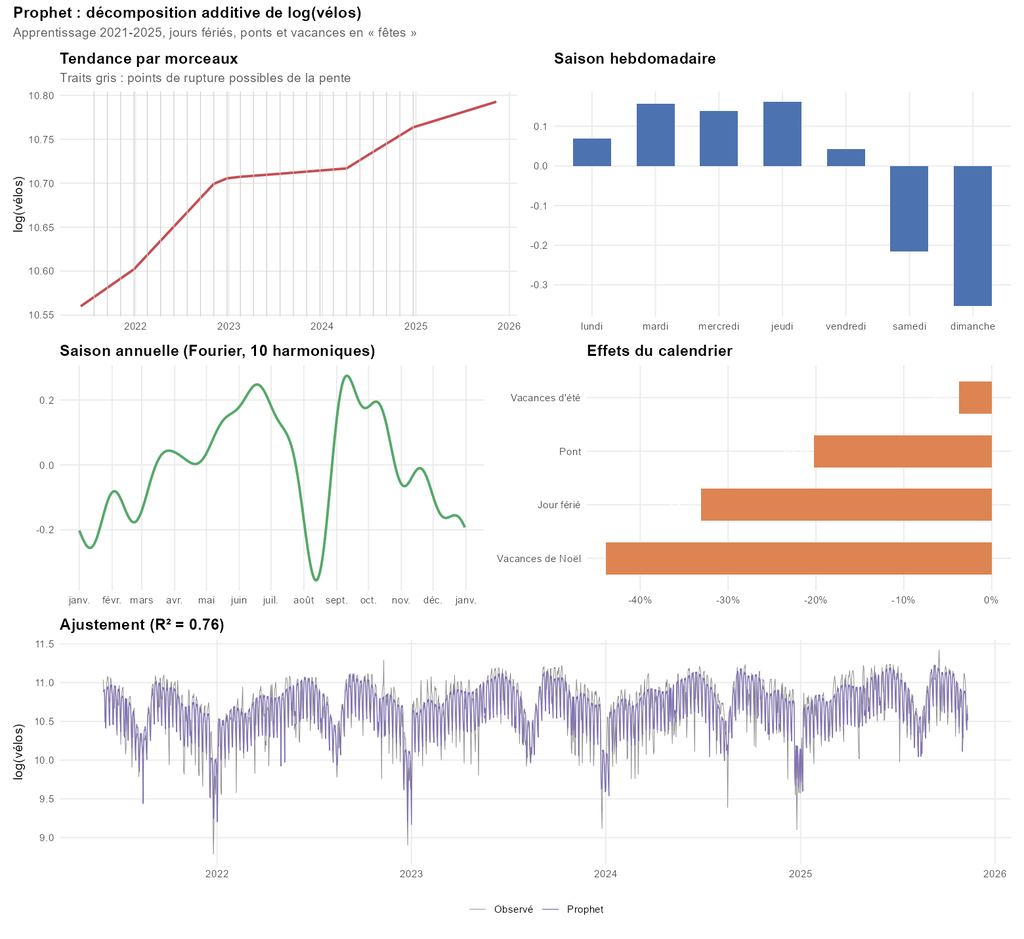

Décomposition par Prophet : tendance par morceaux, saisons de Fourier, effets du calendrier.

Prophet écrit $y(t) = g(t) + s(t) + h(t) + \varepsilon_t$ : tendance linéaire par morceaux, saisons de Fourier et effets des fêtes. La tendance progresse par paliers (forte croissance en 2021-2022, plateau en 2023, reprise en 2024-2025), avec les mêmes effets du calendrier.

# 5 Ruptures et événements

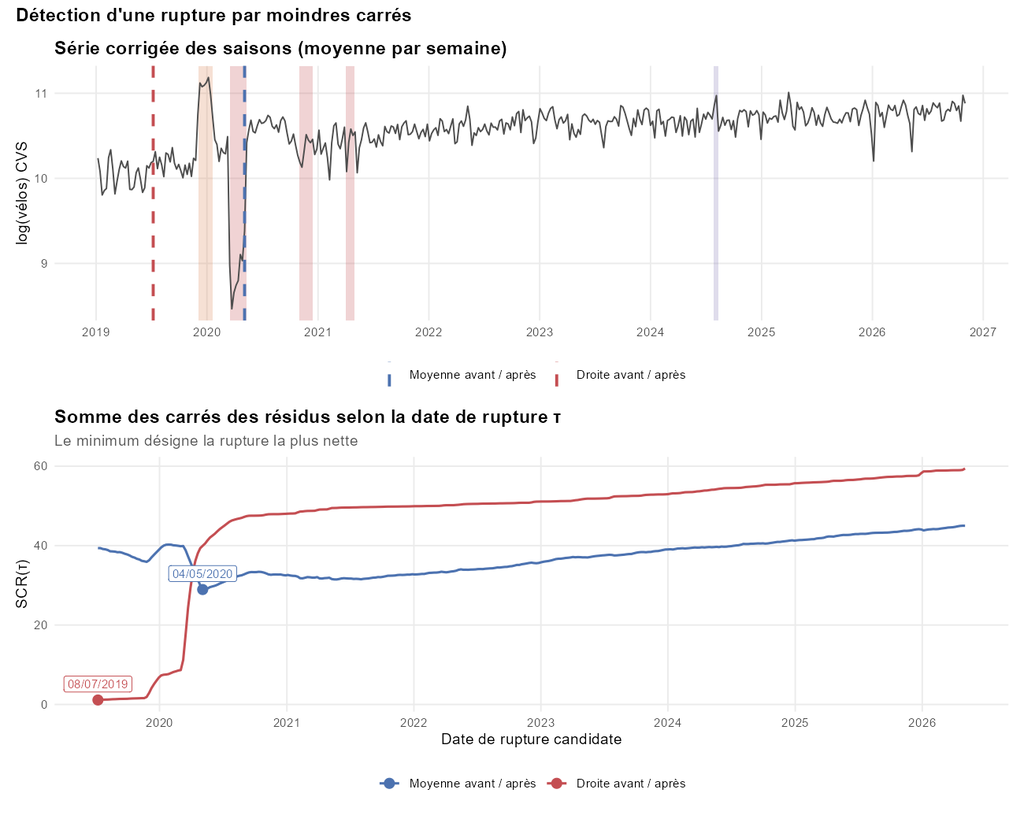

Détection d’une rupture par minimisation de la somme des carrés des résidus .

Sur la série corrigée des variations saisonnières (moyenne hebdomadaire), on cherche la date $\tau$ qui minimise la somme des carrés des résidus d’un modèle « moyenne avant / moyenne après ». Elle désigne la **sortie du premier confinement**.

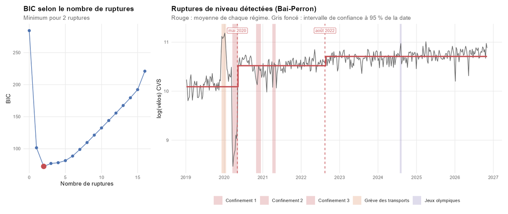

Ruptures multiples (Bai-Perron), nombre choisi par BIC.

L’algorithme de Bai-Perron (programmation dynamique) retient 2 ruptures de niveau : mai 2020 et août 2022. La première est le **changement de régime post-Covid** (essor du vélo, pistes « coronapistes ») ; la seconde traduit la croissance continue, que des moyennes constantes ne peuvent décrire que par paliers.

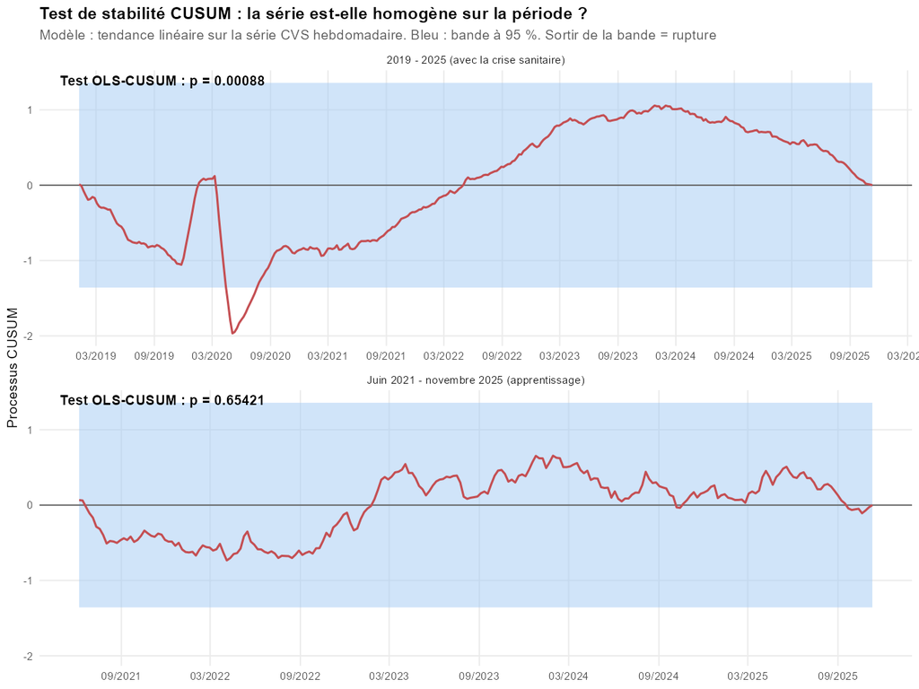

Test de stabilité OLS-CUSUM.

Le test CUSUM rejette nettement la stabilité sur 2019-2025 (p = 0.00088), mais **pas sur la période d’apprentissage** (p = 0,65) : depuis juin 2021, une tendance linéaire stable suffit. Ce résultat justifie le découpage retenu.

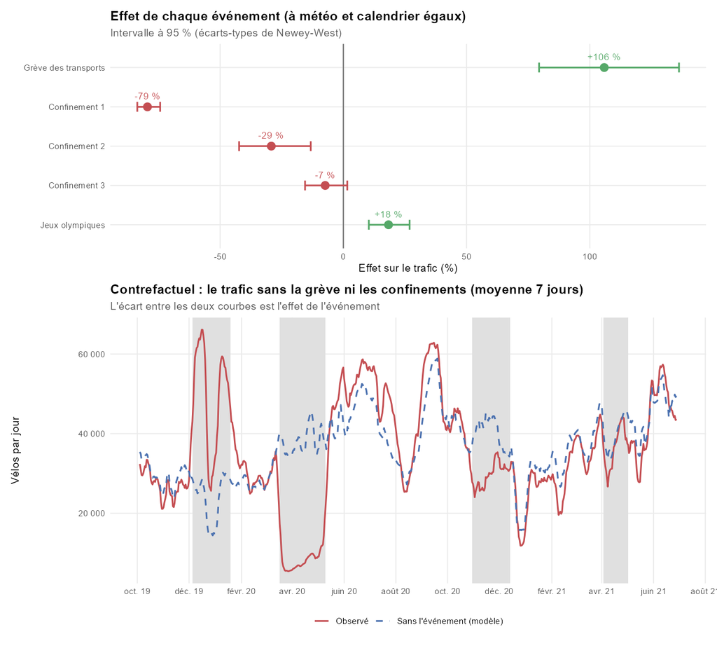

Analyse d’intervention : effet de chaque événement, à météo et calendrier égaux.

Une régression avec une indicatrice par événement (écarts-types de Newey-West pour tenir compte de l’autocorrélation) donne :

[output not shown]

La **grève de décembre 2019** a doublé le trafic : faute de métro, les Parisiens ont pris le vélo. Le **premier confinement** l’a divisé par cinq. Le troisième confinement, plus souple, n’a pas d’effet significatif. Pendant les **Jeux olympiques**, le trafic a été supérieur à un été normal.

# 6 Stationnarité

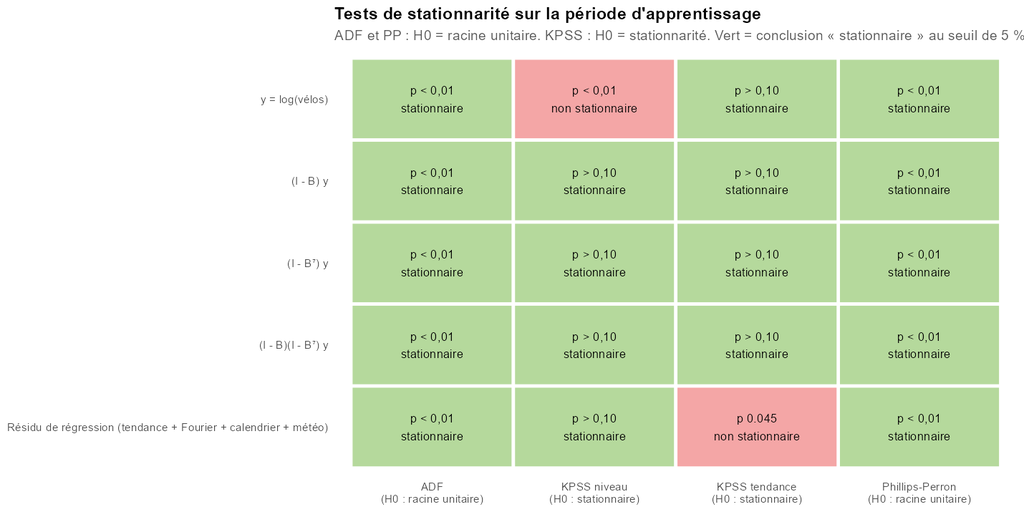

Tests ADF, Phillips-Perron et KPSS sur chaque version de la série.

Les tests ADF et PP (H0 : racine unitaire) et KPSS (H0 : stationnarité) se complètent. Pour $y = \log X$, ADF et PP rejettent la racine unitaire. KPSS rejette la stationnarité autour d’une constante, mais pas autour d’une tendance : $y$ est **stationnaire autour d’une tendance déterministe**, sans racine unitaire ordinaire ($d = 0$).

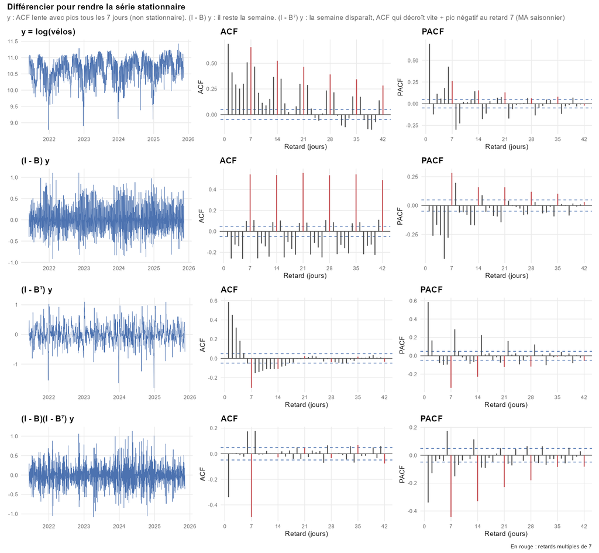

Chronogrammes, ACF et PACF après différenciation.

La différence saisonnière $(I - B^7)\,y$ fait disparaître la semaine : son ACF décroît vite, avec un pic négatif au retard 7, signature d’un MA saisonnier. Tous les tests la déclarent stationnaire. Les choix automatiques sont partagés. `ndiffs` donne $d = 0$ avec ADF et PP, mais $d = 1$ avec KPSS, qui teste la stationnarité autour d’une constante et ignore la tendance. `nsdiffs` donne $D = 0$ (test OCSB) ou $D = 1$ (test de saisonnalité) : la saison hebdomadaire est à la frontière entre stochastique et déterministe, ce que la partie 7 va trancher. On part sur $d = 0$, $D = 1$.

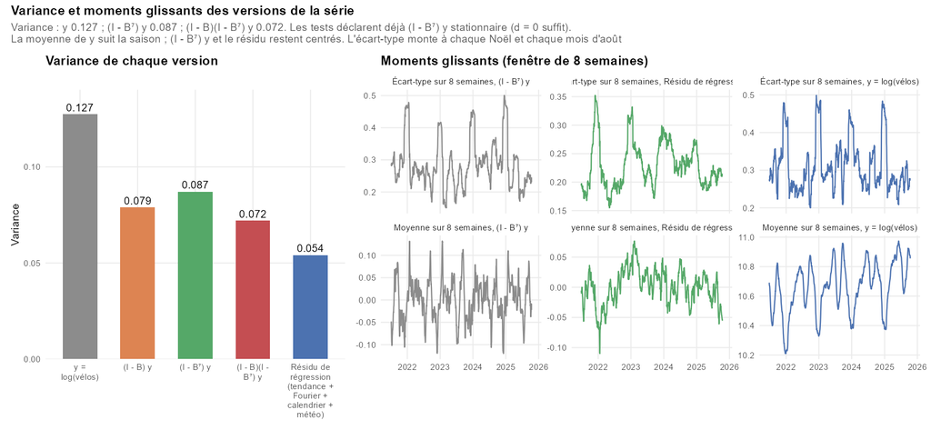

Variance et moments glissants.

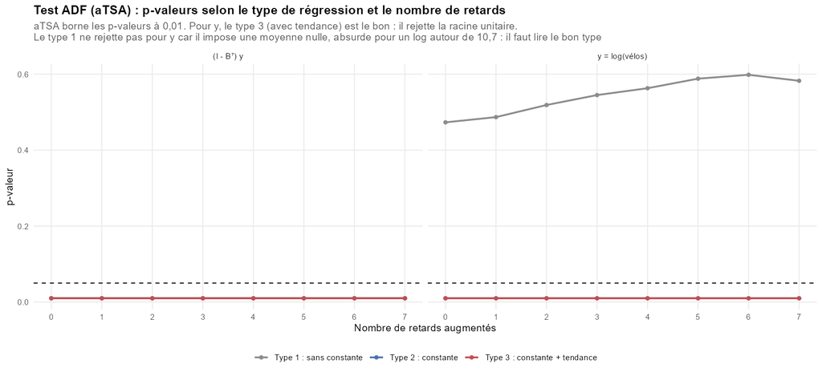

ADF du package aTSA : trois types de régression, 0 à 7 retards augmentés.

Avec `aTSA::adf.test`, il faut **lire le bon type**. Pour $y$, le type 1 (ni constante ni tendance) ne rejette pas la racine unitaire, car il impose une moyenne nulle, ce qui est absurde pour un log autour de 10,7. Les types 2 et 3 la rejettent nettement. Le graphique de $y$ (une tendance) désigne le type 3 : la conclusion « stationnaire autour d’une tendance » est confirmée.

# 7 Modèle SARIMA

## 7.1 Identification et sélection

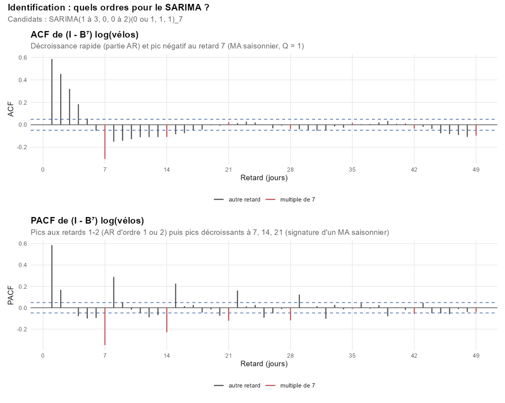

ACF et PACF de la série différenciée.

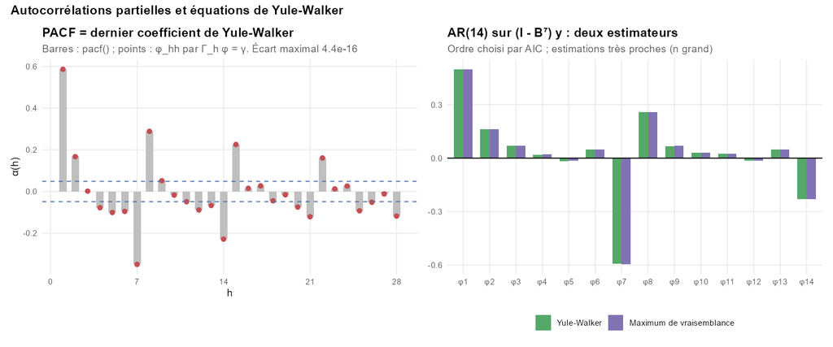

La PACF est le dernier coefficient des équations de Yule-Walker ; estimation d’un AR par Yule-Walker et par maximum de vraisemblance.

La PACF $\alpha(h)$ est le dernier coefficient $\varphi_{hh}$ de la projection de $X_h$ sur $(X_0, \dots, X_{h-1})$. En résolvant $\Gamma_h \varphi = (\gamma(1), \dots, \gamma(h))'$ pour chaque $h$, on retrouve exactement `pacf()` (écart de l’ordre de $10^{-16}$). Les coefficients $\varphi_{h1}, \dots, \varphi_{hh}$ changent avec $h$, d’où la double indexation. Pour un AR ajusté sur $(I - B^7)\,y$, Yule-Walker et le maximum de vraisemblance donnent des estimations presque identiques, ce qui est attendu avec 1 600 observations. Rappel : on ne lit pas les ordres d’un ARMA sur l’ACF et la PACF. On s’en sert pour proposer des candidats, puis on choisit par critère d’information.

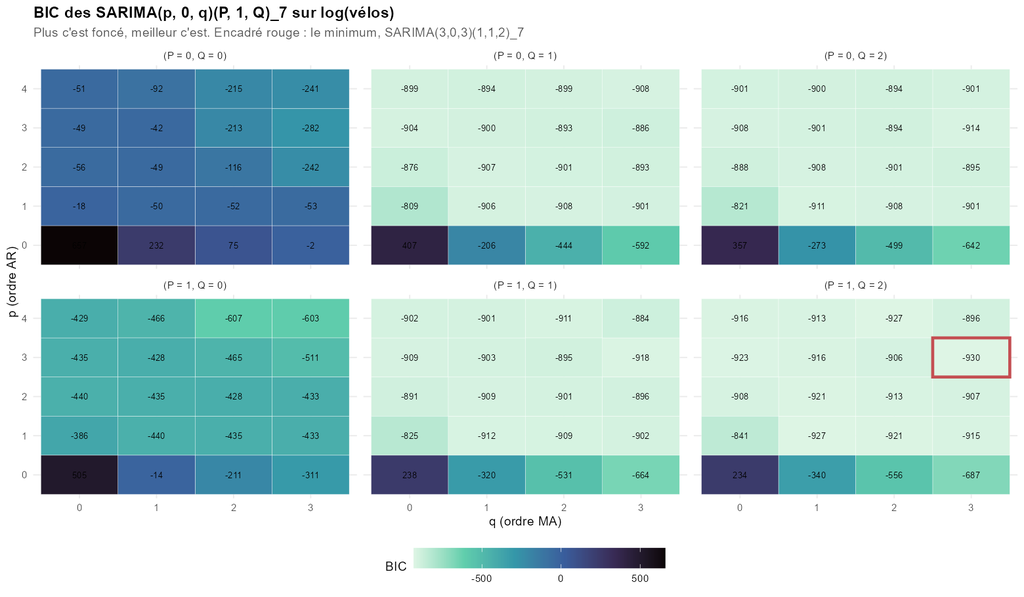

BIC des 120 SARIMA(p,0,q)(P,1,Q)_7 estimés.

On estime 120 modèles SARIMA$(p,0,q)(P,1,Q)_7$ avec dérive, pour $p \le 4$, $q \le 3$, $P \le 1$, $Q \le 2$. Le BIC retient le **SARIMA(3,0,3)(1,1,2)_7** (BIC -930,4), alors que la recherche pas à pas d’`auto.arima` ne trouve que ARIMA(3,0,0)(2,1,0)[7] (BIC -635,2).